# linear regression

Arash Hatamirad, ahatamirad@gmail.com

9/1/2021

## linear regression

We will use heart.csv dataset. Below is brief summary of variables in heart.csv.

- Weight: subject’s weight
- Systolic: top number in a blood pressure reading, indicating the blood pressure level when the heart contracts
- Diastolic: bottom number in a blood pressure reading, indicating the blood pressure level when the heart is at rest or between beats
- Cholesterol: measured cholesterol

The data set contains Weight, Diastolic Blood pressure, Systolic blood pressure and Cholesterol for alive subjects in the heart.csv.

```r
# Read the CSV file
d1 <- read.csv("heart.csv")

# Check data format
#str(d1)
```

The medical director at your company wants to know if Weight alone can predict Cholesterol outcomes. Consider modeling Cholesterol as a function of Weight.

#### Question (a):

- Fit a linear regression model for Cholesterol as a function of Weight. If any points are unduly influential, note those points, then remove them and refit the model. Consider Cook’s distance cut off to be 0.015.

#### Answer -:

##### Step 1) Scatter Plot

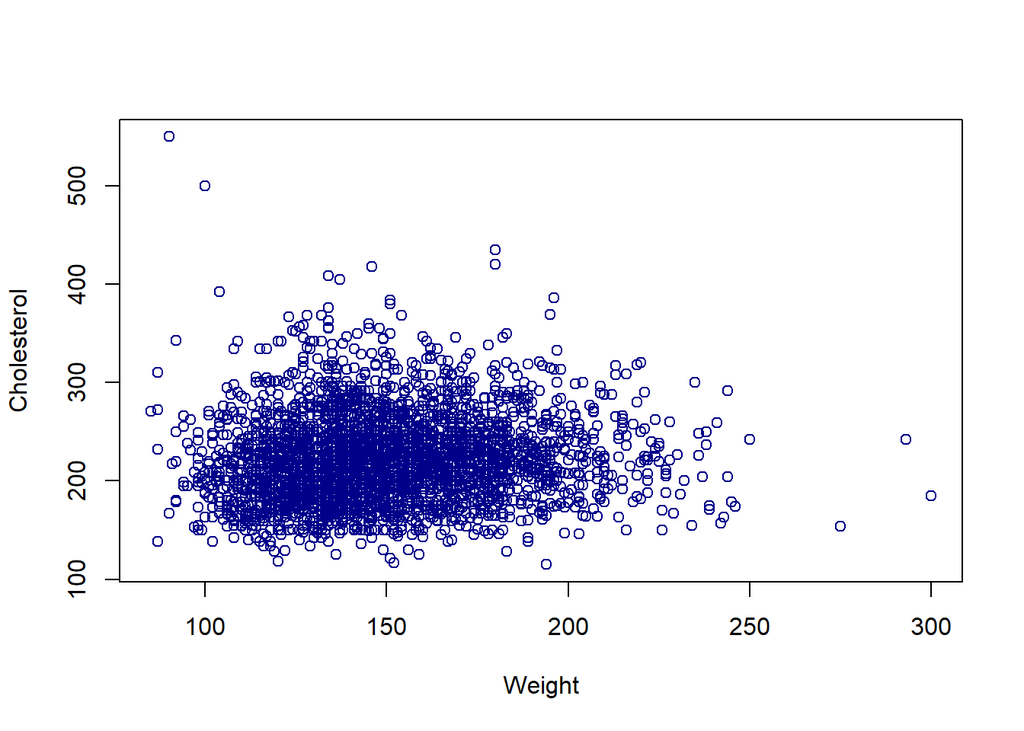

```r
plot(data=d1, Cholesterol ~ Weight,col="darkblue")
```

##### Step 2) Find Correlation coefficient

```r
cor(d1$Weight,d1$Cholesterol,method = "pearson")
```

```
## [1] 0.0695377
```

```r
cor(d1$Cholesterol,d1$Weight,method = "spearman")
```

```
## [1] 0.1078544
```

“Person” correlation is sensitive and “spearman” correlation is robust to outliers.

##### Step 3) Fit Linear Regression

```r
e1.lr <- lm( Cholesterol ~ Weight  , data=d1)
summary(e1.lr)
```

```
##
## Call:
## lm(formula = Cholesterol ~ Weight, data = d1)
##
## Residuals:
##     Min      1Q  Median      3Q     Max
## -111.95  -29.59   -4.64   23.49  334.35
##
## Coefficients:
##              Estimate Std. Error t value Pr(>|t|)
## (Intercept) 205.86763    4.24729  48.470  < 2e-16 ***
## Weight        0.10867    0.02786   3.901 9.78e-05 ***
## ---
## Signif. codes:  0 '***' 0.001 '**' 0.01 '*' 0.05 '.' 0.1 ' ' 1
##
## Residual standard error: 43.62 on 3132 degrees of freedom
## Multiple R-squared:  0.004835,   Adjusted R-squared:  0.004518
## F-statistic: 15.22 on 1 and 3132 DF,  p-value: 9.778e-05
```

##### Result:

For F-Statistic, is significant and P-Value < 0.05 (very small), thus we don’t have any evidence to accept Null, therefor the model is useful.  
In the other word, there exist linear regression for cholestrol as a function of weight.

##### Linear regression model:

```
    ŷ = 205.86763 + 0.10867 * Weight
```

##### R Square (R2):

R Square is very small, thus, “Goodness of fit” or “Predictive power” is very low.

##### Step 4) Now draw a scatter plot again, include the regression line

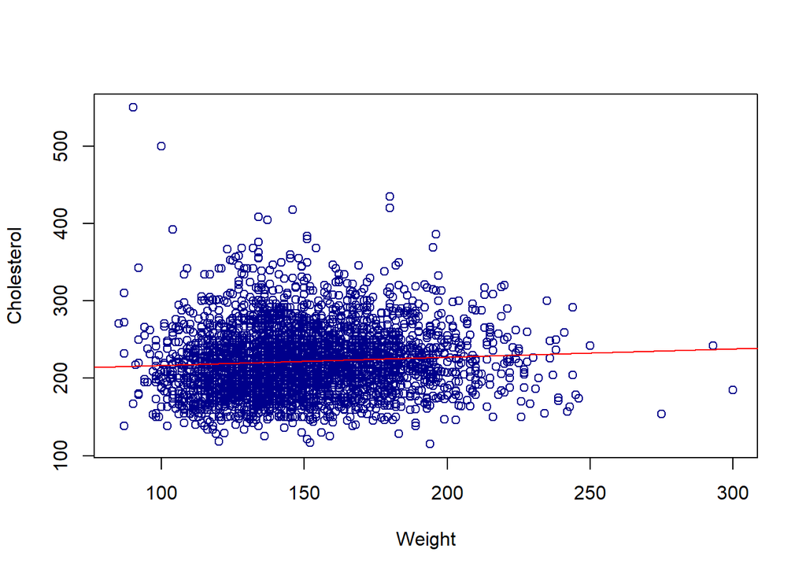

```r
with(d1, plot(Cholesterol ~ Weight,col="darkblue"))
abline(e1.lr,col="red")
```

##### Step 5) Diagnostic plots

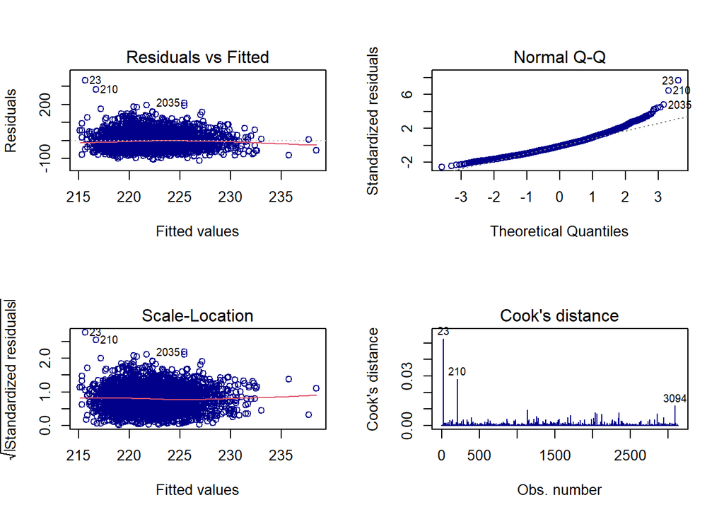

```r
par(mfrow=c(2,2))
plot(e1.lr, which=c(1:4),col="darkblue")    # default diagnostics plots
```

##### Step 6) Influential Points

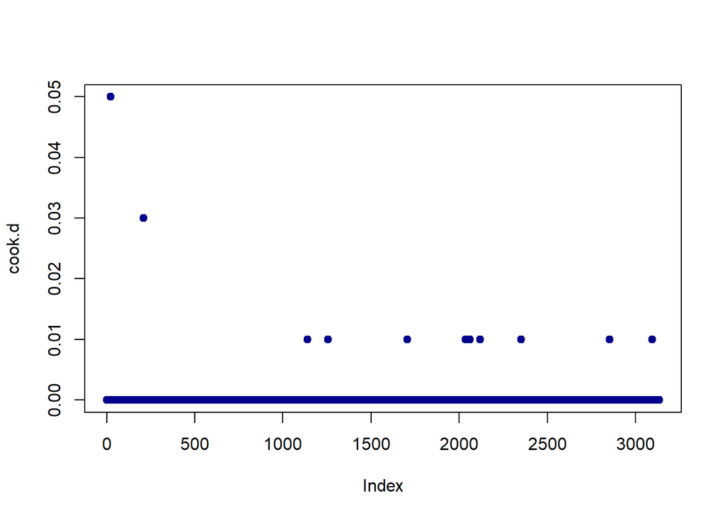

```r
cook.d <- round(cooks.distance(e1.lr),2)
plot(cook.d,col="darkblue", pch=19, cex=1)
```

##### Step 7) Delete Influential Points

Delete observations larger than criteria (0.015)

```r
inf.id <- which(cooks.distance(e1.lr) > 0.015)
#d1[inf.id, ]
e1.lr2 <- lm(Cholesterol ~ Weight, data=d1[-inf.id, ])
summary(e1.lr2)
```

```
##
## Call:
## lm(formula = Cholesterol ~ Weight, data = d1[-inf.id, ])
##
## Residuals:
##      Min       1Q   Median       3Q      Max
## -112.369  -29.395   -4.482   23.672  209.348
##
## Coefficients:
##              Estimate Std. Error t value Pr(>|t|)
## (Intercept) 203.57605    4.18543  48.639  < 2e-16 ***
## Weight        0.12264    0.02745   4.469 8.16e-06 ***
## ---
## Signif. codes:  0 '***' 0.001 '**' 0.01 '*' 0.05 '.' 0.1 ' ' 1
##
## Residual standard error: 42.92 on 3130 degrees of freedom
## Multiple R-squared:  0.006339,   Adjusted R-squared:  0.006022
## F-statistic: 19.97 on 1 and 3130 DF,  p-value: 8.155e-06
```

##### Linear regression model:

```
    ŷ = 203.57605 + 0.12264 * Weight
```

##### R Square (R2):

R Square is very small, thus, “Goodness of fit” or “Predictive power” is very low.

##### Step 8) Plot scatter, with and without influential points

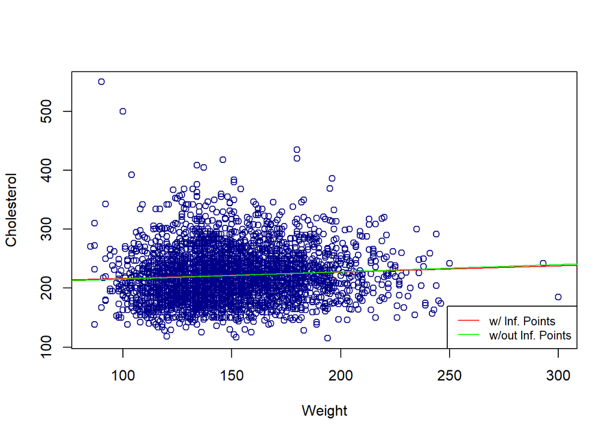

```r
with(d1, plot(Cholesterol ~ Weight,col="darkblue"))
abline(e1.lr,col="red")
abline(e1.lr2,col="green")
legend("bottomright",col=c("red","green"),legend=c("w/ Inf. Points", "w/out Inf. Points"), cex=0.8, title.adj=0.15, lty=1)
```

##### Step 9) Diagnostic plot for without influential points

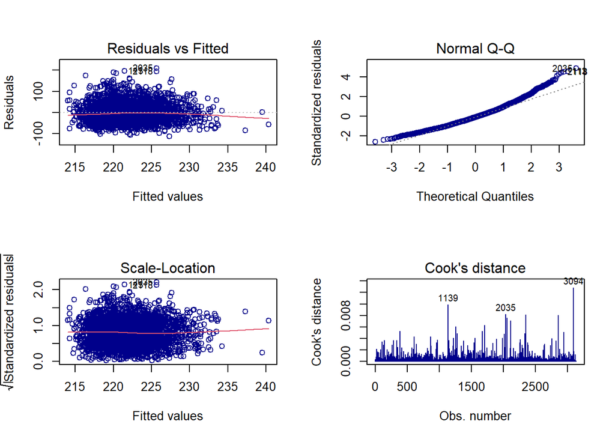

```r
par(mfrow=c(2,2))
plot(e1.lr2, which=c(1:4),col="darkblue")
```

We can see, there is not any Cook’s distance more than criteria value (0.015)

#### Conclusion:

Regression lines with/without influential points are almost the same.

#### Question (b):

- Comment on the significance of the parameters, variation explained by the model, and any remaining issues noted in the diagnostics plots. What does this model tell us about the relationship between Cholesterol and Weight? Interpret the relationship specifically. Explain to the medical director whether this is a good model for the prediction of Cholesterol levels.

#### Answer -:

1. Based on step 2, correlation coefficient (rho) is positive and non-zero thus there is a direct relation.
2. Based on step 3 and step 7 (With/Without), P-Value is significant, thus there exist linear regression for cholesterol as a function of weight.
3. Based on step 3 and step 7 (With/Without), R2 is very small, thus “Power of Prediction” or “Goodness of fit” is not good enough, it means model is useful but is not good enough for prediction.

In the other word, this is not a good model to predict cholesterol by Weight, although the model is useful.